# Student Activity 1: Tables and Counts data

A Course on Data Visualization

Livio Finos, University of Padova

2026-09-29

# A two-by-two table

## Source and variable definitions

[Read the article and Table 2](https://pmc.ncbi.nlm.nih.gov/articles/PMC8763101/).

We call the outcome **colour-vision deficiency (CVD) detected / not detected**, retaining the study’s binary classification. “Not detected” refers to this assessment, not the absence of every possible visual condition. We use **sex (as recorded)** for the reported Male/Female categories; the source labels this variable “gender” and does not establish how sex and gender identity were distinguished. These are sample frequencies, not universal prevalence values.

The original treatment example is replaced by these observed counts. No individual-level records are generated or implied.

```r
tab <- matrix(c(5, 49,
                4, 284), nrow = 2, byrow = TRUE)
dimnames(tab) <- list(
  Sex = c("Male", "Female"),
  CVD = c("Detected", "Not detected")
)
# Complements: 54 - 5 = 49 and 288 - 4 = 284.
knitr::kable(addmargins(tab), caption = "Observed counts with marginal totals.")
```

Observed counts with marginal totals.

|  | Detected | Not detected | Sum |
| --- | --- | --- | --- |
| Male | 5 | 49 | 54 |
| Female | 4 | 284 | 288 |
| Sum | 9 | 333 | 342 |

```r
stopifnot(sum(tab) == 342, all(rowSums(tab) == c(54, 288)),
          all(colSums(tab) == c(9, 333)))
```

**Before plotting:** which sex contributes more participants? Which contributes more detected cases? Are those two questions equivalent to comparing the proportion with detected CVD?

```r
dat <- as.data.frame(as.table(tab))
dat$Sex <- factor(dat$Sex, levels = rownames(tab))
dat$CVD <- factor(dat$CVD, levels = colnames(tab))
dat$sex_total <- as.numeric(rowSums(tab)[as.character(dat$Sex)])
dat$status_total <- as.numeric(colSums(tab)[as.character(dat$CVD)])
dat$p_within_sex <- dat$Freq / dat$sex_total
dat$p_within_status <- dat$Freq / dat$status_total
sex_axis <- setNames(paste0(rownames(tab), "\n(n = ", rowSums(tab), ")"), rownames(tab))
status_axis <- setNames(paste0(colnames(tab), "\n(n = ", colSums(tab), ")"), colnames(tab))
```

## Absolute frequencies: how many participants?

**Question:** how many participants in each sex category had CVD detected or not detected?

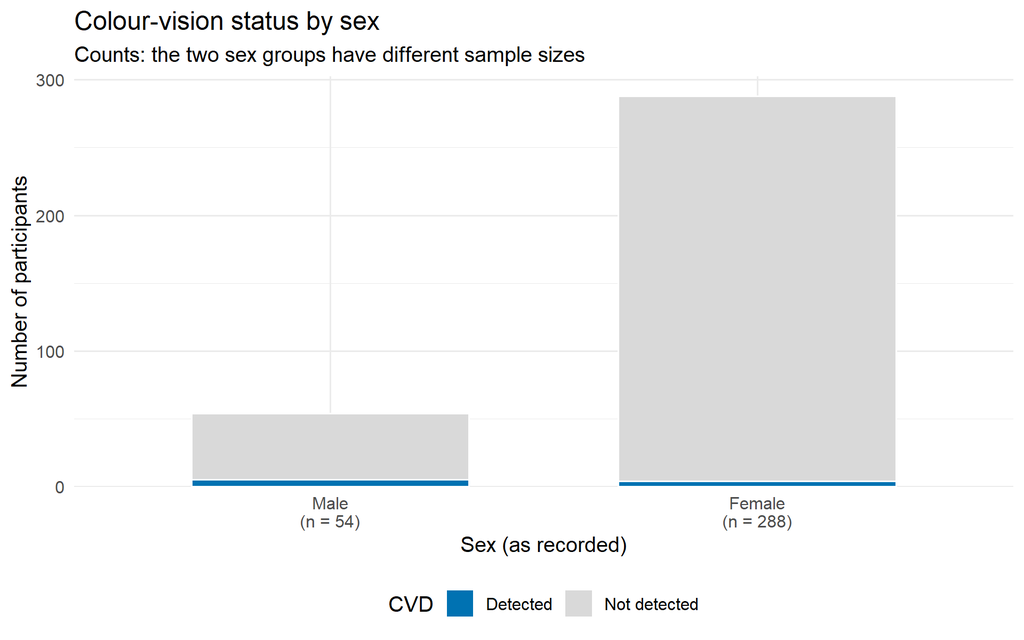

Stacked counts show both sample sizes and outcome counts. The detected segment starts at zero.

```r
p_counts <- ggplot(dat, aes(Sex, Freq, fill = CVD)) +
  geom_col(position = position_stack(reverse = TRUE), width = .65, colour = "white") +
  scale_fill_manual(values = cvd_colours) +
  scale_x_discrete(labels = sex_axis) +
  scale_y_continuous(expand = expansion(mult = c(0, .05))) +
  labs(title = "Colour-vision status by sex",
       subtitle = "Counts: the two sex groups have different sample sizes",
       x = "Sex (as recorded)", y = "Number of participants", fill = "CVD") +
  theme(legend.position = "bottom")
p_counts
```

### Compare the four counts with equal-width bars

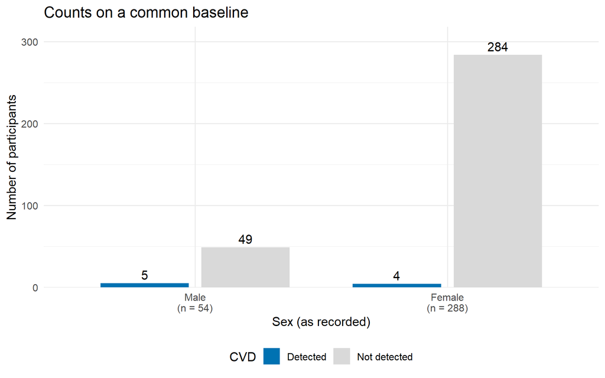

```r
ggplot(dat, aes(Sex, Freq, fill = CVD)) +
  geom_col(position = position_dodge(width = .8, preserve = "single"), width = .7) +
  geom_text(aes(label = Freq), position = position_dodge(width = .8), vjust = -.4) +
  scale_fill_manual(values = cvd_colours) +
  scale_x_discrete(labels = sex_axis) +
  scale_y_continuous(expand = expansion(mult = c(0, .12))) +
  labs(title = "Counts on a common baseline", x = "Sex (as recorded)",
       y = "Number of participants", fill = "CVD") +
  theme(legend.position = "bottom")
```

The side-by-side bars make each outcome count directly comparable. Their baseline remains zero, and the labels make the small counts visible.

## Conditional proportions: colour-vision status given sex

**Question:** within each sex group, what proportion had CVD detected?

For a sex category $s$, the empirical conditional proportion is

$$\widehat P(\mathrm{CVD}=\mathrm{Detected}\mid\mathrm{Sex}=s)
=\frac{n_{s,\mathrm{Detected}}}{n_{s,+}}.$$

Here the denominator is a **row total**, since rows correspond to sex.

```r
within_sex <- prop.table(tab, margin = 1)
knitr::kable(100 * within_sex, digits = 2,
             caption = "Percentages within sex: each row sums to 100%.")
```

Percentages within sex: each row sums to 100%.

|  | Detected | Not detected |
| --- | --- | --- |
| Male | 9.26 | 90.74 |
| Female | 1.39 | 98.61 |

```r
stopifnot(all(abs(rowSums(within_sex) - 1) < 1e-12))
```

### Bars normalised to 100%

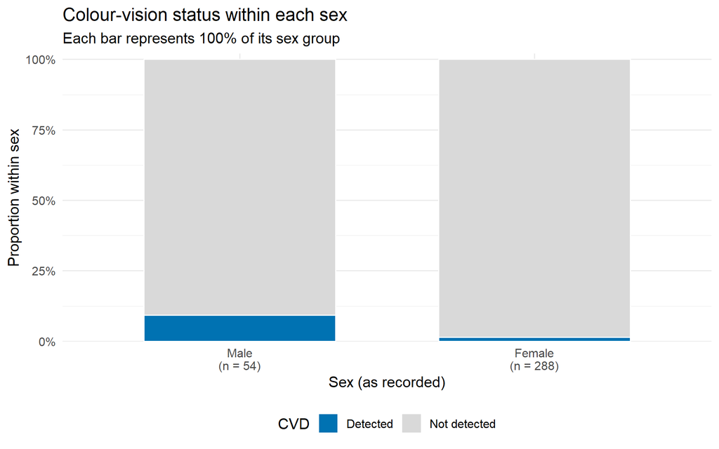

```r
p_within_sex <- ggplot(dat, aes(Sex, Freq, fill = CVD)) +
  geom_col(position = position_fill(reverse = TRUE), width = .65, colour = "white") +
  scale_fill_manual(values = cvd_colours) +
  scale_x_discrete(labels = sex_axis) +
  scale_y_continuous(labels = scales::label_percent(),
                     expand = expansion(mult = c(0, .02))) +
  labs(title = "Colour-vision status within each sex",
       subtitle = "Each bar represents 100% of its sex group",
       x = "Sex (as recorded)", y = "Proportion within sex", fill = "CVD") +
  theme(legend.position = "bottom")
p_within_sex
```

The detected proportions are **5/54 = 9.26% among males** and **4/288 = 1.39% among females**. Normalisation removes the difference in total bar heights; the labels retain the sample sizes.

### Show only the proportion of interest

Because CVD is uncommon in this sample, the blue segments occupy a small part of the 100% bars. If the question concerns only detected CVD, show that proportion directly.

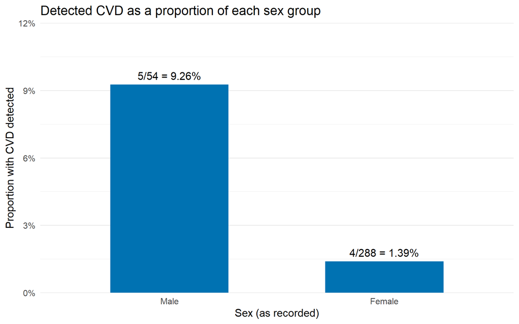

The axis starts at zero and focuses on detected CVD. Labels include both numerator and denominator.

```r
detected <- subset(dat, CVD == "Detected")
detected$label <- sprintf("%d/%d = %.2f%%", detected$Freq,
                          detected$sex_total, 100 * detected$p_within_sex)
p_detected <- ggplot(detected, aes(Sex, p_within_sex)) +
  geom_col(fill = cvd_colours["Detected"], width = .55) +
  geom_text(aes(label = label), vjust = -.6) +
  scale_y_continuous(labels = scales::label_percent(accuracy = 1),
                     limits = c(0, .12), expand = expansion(mult = c(0, 0))) +
  labs(title = "Detected CVD as a proportion of each sex group",
       x = "Sex (as recorded)", y = "Proportion with CVD detected") +
  theme(panel.grid.major.x = element_blank())
p_detected
```

## Reverse the conditioning: sex given colour-vision status

**A different question:** among participants with CVD detected, what proportion were male or female?

$$\widehat P(\mathrm{Male}\mid\mathrm{Detected})=\frac59=55.56\%,
\qquad
\widehat P(\mathrm{Detected}\mid\mathrm{Male})=\frac5{54}=9.26\%.$$

The numerator is the same cell of the table. The denominator and interpretation are different.

```r
within_status <- prop.table(tab, margin = 2)
knitr::kable(100 * within_status, digits = 2,
             caption = "Percentages within colour-vision status: each column sums to 100%.")
```

Percentages within colour-vision status: each column sums to 100%.

|  | Detected | Not detected |
| --- | --- | --- |
| Male | 55.56 | 14.71 |
| Female | 44.44 | 85.29 |

```r
stopifnot(all(abs(colSums(within_status) - 1) < 1e-12))
```

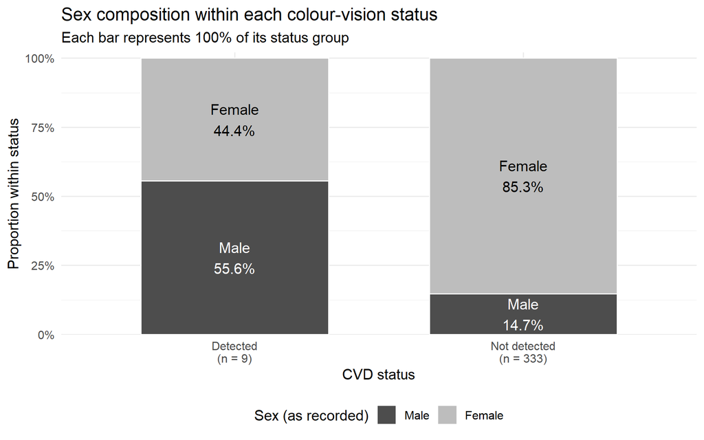

The denominator is now the number of participants in each colour-vision status category.

```r
sex_colours <- c("Male" = "#4D4D4D", "Female" = "#BDBDBD")
p_reverse <- ggplot(dat, aes(CVD, p_within_status, fill = Sex)) +
  geom_col(position = position_stack(reverse = TRUE), width = .65, colour = "white") +
  geom_text(aes(label = sprintf("%s\n%.1f%%", Sex, 100 * p_within_status), colour = Sex),
            position = position_stack(vjust = .5, reverse = TRUE), show.legend = FALSE) +
  scale_colour_manual(values = c(Male = "white", Female = "black"), guide = "none") +
  scale_fill_manual(values = sex_colours) +
  scale_x_discrete(labels = status_axis) +
  scale_y_continuous(labels = scales::label_percent(),
                     expand = expansion(mult = c(0, .02))) +
  labs(title = "Sex composition within each colour-vision status",
       subtitle = "Each bar represents 100% of its status group",
       x = "CVD status", y = "Proportion within status", fill = "Sex (as recorded)") +
  theme(legend.position = "bottom")
p_reverse
```

## Compare the questions side by side

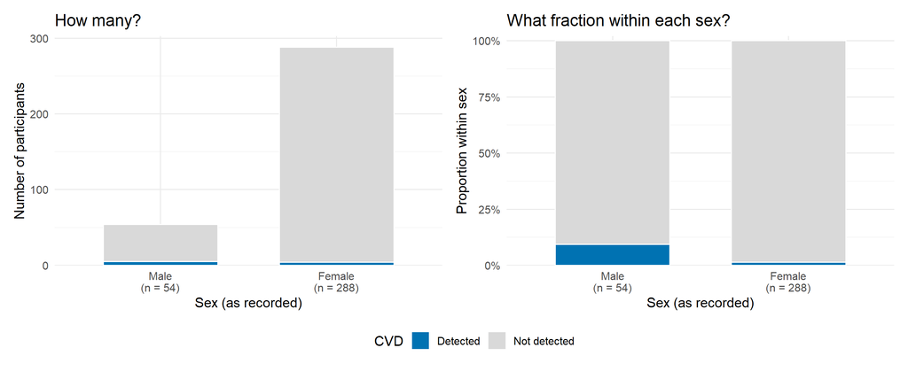

The same table supports counts and conditional proportions, but these answer different questions.

[output not shown]

```r
(p_counts + labs(title = "How many?", subtitle = NULL)) +
  (p_within_sex + labs(title = "What fraction within each sex?", subtitle = NULL)) +
  plot_layout(guides = "collect") & theme(legend.position = "bottom")
```

**The appropriate graph depends on the question. Counts show numbers; conditional proportions compare distributions within explicitly defined groups. Changing the conditioning variable changes the denominator.**

## Optional: a mosaic plot

A mosaic plot can encode group size and conditional distribution together. In the plot below, column widths represent the sex-group proportions; segment heights represent the CVD proportions within each sex. Rectangle areas therefore represent joint sample proportions.

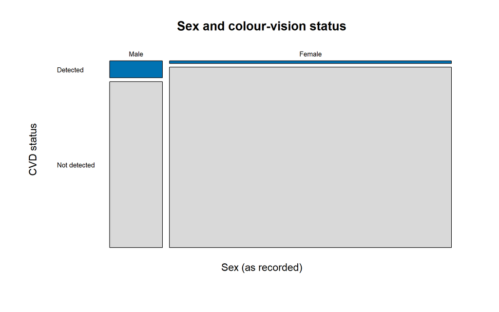

Mosaic plot: widths encode sex-group sizes; heights encode status proportions within sex; areas encode joint proportions.

```r
mosaicplot(tab, color = unname(cvd_colours[colnames(tab)]),
           main = "Sex and colour-vision status",
           xlab = "Sex (as recorded)", ylab = "CVD status", las = 1)
```

The narrower male column reflects its smaller sample size. The small detected group makes some rectangles thin; the table and direct labels in earlier plots remain useful for exact reading. A mosaic plot provides more information at once but requires more explanation than aligned bars.

## Reference and reproducibility

Ngente, Z., Jadav, B., Aafaque, S., Patil, A., Govindarajulu, R., Muthusamy, P., et al. (2021). *Prevalence of Color Vision Anomalies among Dental Professionals*. **Middle East African Journal of Ophthalmology**, 28, 169–173. Data: Table 2. [Full text](https://pmc.ncbi.nlm.nih.gov/articles/PMC8763101/).

To render, install `rmarkdown`, `knitr`, `ggplot2`, `scales`, and `patchwork`, then run:

```r
rmarkdown::render("conditional_barplots_colour_vision.Rmd")
```

# Relationship between two count variables

Suppose we observe, for 443 students:

```r
library(tidyverse)

set.seed(123)

students <- tibble(
  student_id = 1:300,
  classes_attended = rbinom(300, size = 10, prob = 0.65)
) |>
  mutate(
    p_submit = plogis(-1.5 + 0.30 * classes_attended),
    assignments_submitted = rbinom(300, size = 12, prob = p_submit)
  )

students$p_submit=NULL
eg=expand.grid(0:10,0:12)
colnames(eg)=colnames(students)[-1]
eg=data.frame(student_id=nrow(students)+1:nrow(eg),eg)
students=rbind(students,eg)

write.csv(file="./data/students.csv",students)
```

### Why an ordinary scatter plot is inadequate

Both variables are discrete. Consequently, many students have exactly the same pair of values.

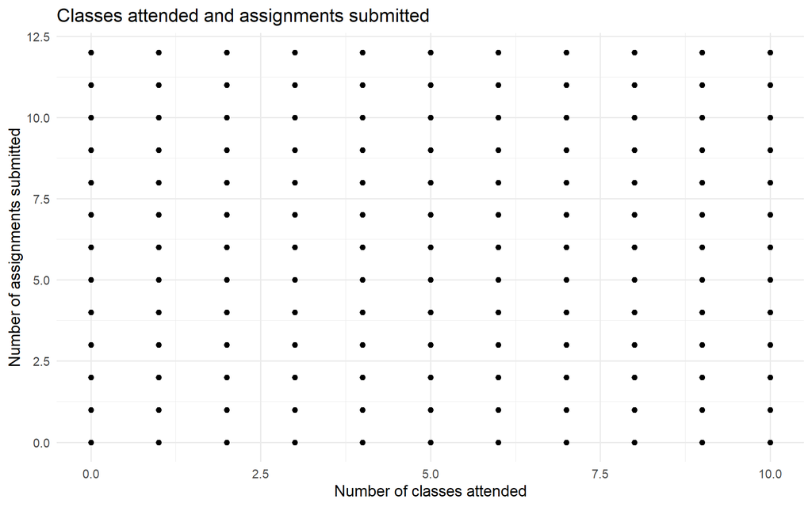

```r
ggplot(
  students,
  aes(x = classes_attended, y = assignments_submitted)
) +
  geom_point() +
  labs(
    title = "Classes attended and assignments submitted",
    x = "Number of classes attended",
    y = "Number of assignments submitted"
  ) +
  theme_minimal()
```

Several observations are drawn in precisely the same position. The graph therefore hides the frequency of the different combinations: a point may represent one student or many students.

## Proposal 1: count plot

A count plot represents each observed combination with a circle whose area is proportional to its frequency.

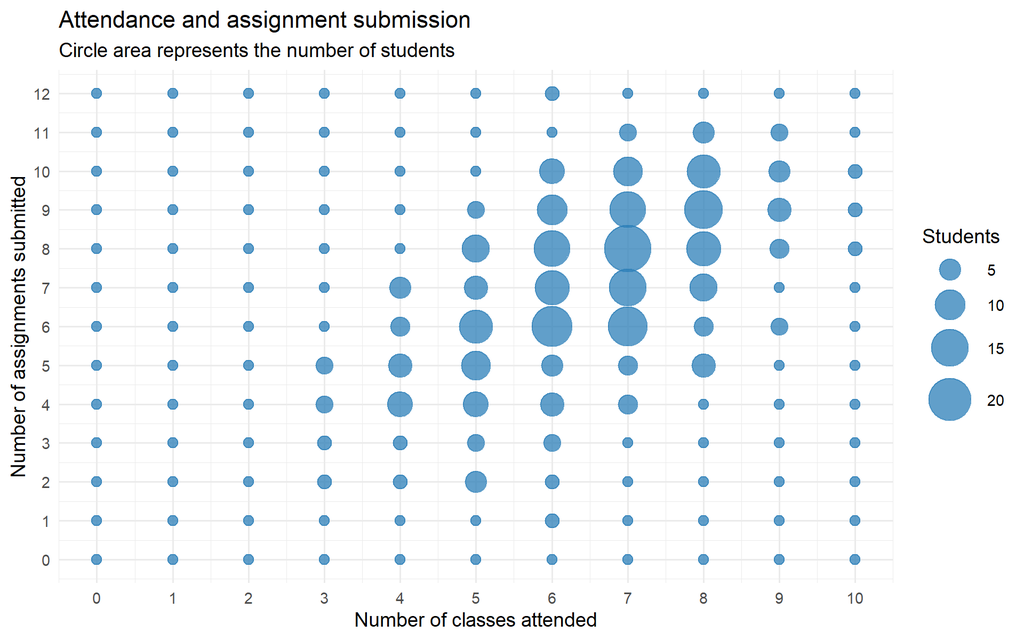

```r
ggplot(
  students,
  aes(x = classes_attended, y = assignments_submitted)
) +
  geom_count(colour = "#2C7FB8", alpha = 0.75) +
  scale_size_area(max_size = 12) +
  scale_x_continuous(breaks = 0:10) +
  scale_y_continuous(breaks = 0:12) +
  labs(
    title = "Attendance and assignment submission",
    subtitle = "Circle area represents the number of students",
    x = "Number of classes attended",
    y = "Number of assignments submitted",
    size = "Students"
  ) +
  theme_minimal()
```

This graph preserves the observed integer values while making repeated combinations visible.

## Proposal 2: joint-frequency heatmap

An alternative is to count the observations in each cell and represent frequency using colour.

[figure not shown]

```r
joint_counts <- students |>
  count(classes_attended, assignments_submitted)

ggplot(
  joint_counts,
  aes(
    x = classes_attended,
    y = assignments_submitted,
    fill = n
  )
) +
  geom_tile(colour = "white") +
  scale_x_continuous(breaks = 0:10) +
  scale_y_continuous(breaks = 0:12) +
  scale_fill_viridis_c(option = "C") +
  coord_equal() +
  labs(
    title = "Joint distribution of attendance and submissions",
    subtitle = "Darker cells contain more students",
    x = "Number of classes attended",
    y = "Number of assignments submitted",
    fill = "Students"
  ) +
  theme_minimal()
```

The heatmap is particularly effective when there are many repeated combinations.

## Proposal 3 Count plot with jitter

### Scatter plot with a small amount of jitter

Jittering adds a small random displacement to overlapping points. The displacement makes individual observations more visible while preserving the discrete structure of the data.

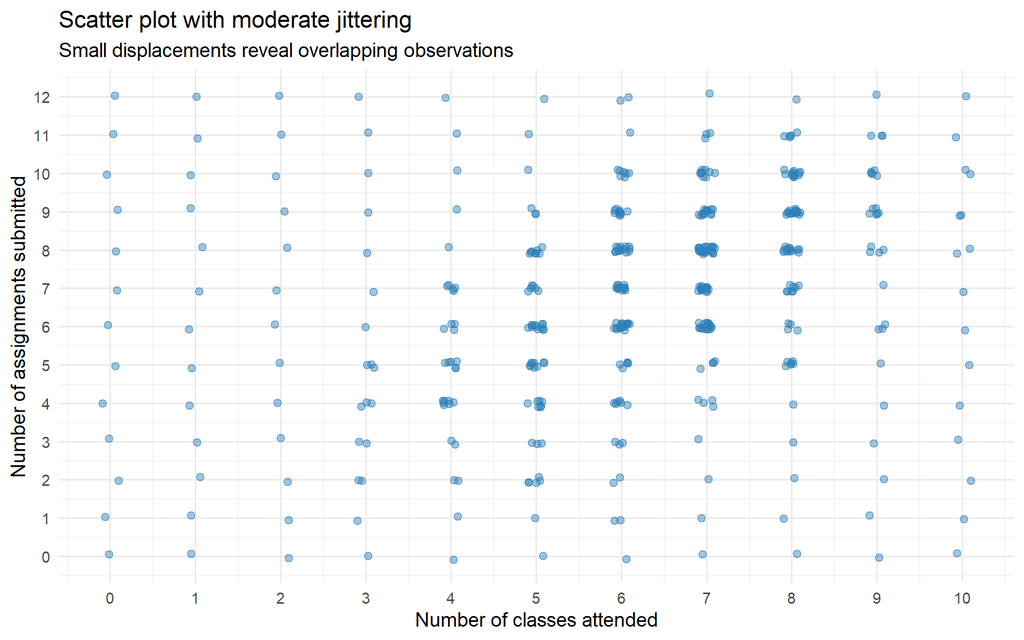

```r
set.seed(123)

ggplot(
  students,
  aes(x = classes_attended, y = assignments_submitted)
) +
  geom_jitter(
    width = 0.10,
    height = 0.10,
    size = 1.8,
    alpha = 0.45,
    colour = "#2C7FB8"
  ) +
  scale_x_continuous(breaks = 0:10) +
  scale_y_continuous(breaks = 0:12) +
  labs(
    title = "Scatter plot with moderate jittering",
    subtitle = "Small displacements reveal overlapping observations",
    x = "Number of classes attended",
    y = "Number of assignments submitted"
  ) +
  theme_minimal()
```

The original values are integers. The small horizontal and vertical displacements are graphical devices only: they do not represent measurement error or additional variation in the data.

### Scatter plot with excessive jitter

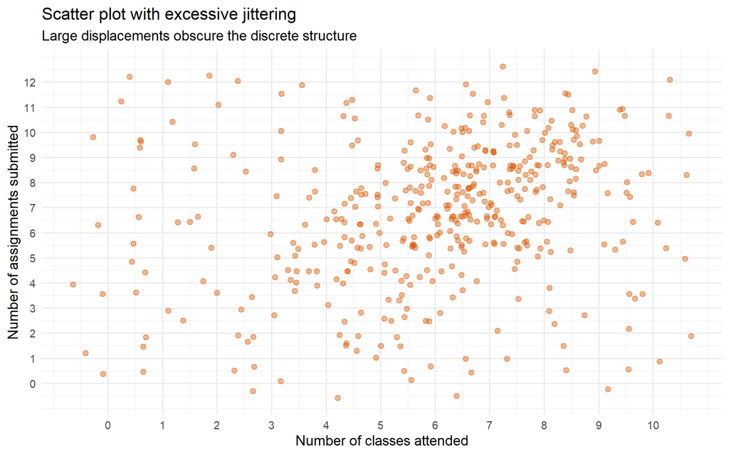

```r
set.seed(123)

ggplot(
  students,
  aes(x = classes_attended, y = assignments_submitted)
) +
  geom_jitter(
    width = 0.70,
    height = 0.70,
    size = 1.8,
    alpha = 0.45,
    colour = "#D95F0E"
  ) +
  scale_x_continuous(breaks = 0:10) +
  scale_y_continuous(breaks = 0:12) +
  labs(
    title = "Scatter plot with excessive jittering",
    subtitle = "Large displacements obscure the discrete structure",
    x = "Number of classes attended",
    y = "Number of assignments submitted"
  ) +
  theme_minimal()
```

Here the displacement is large relative to the distance between consecutive integer values. It creates the misleading impression that fractional counts were observed and makes neighbouring combinations difficult to distinguish.

## Side-by-side comparison

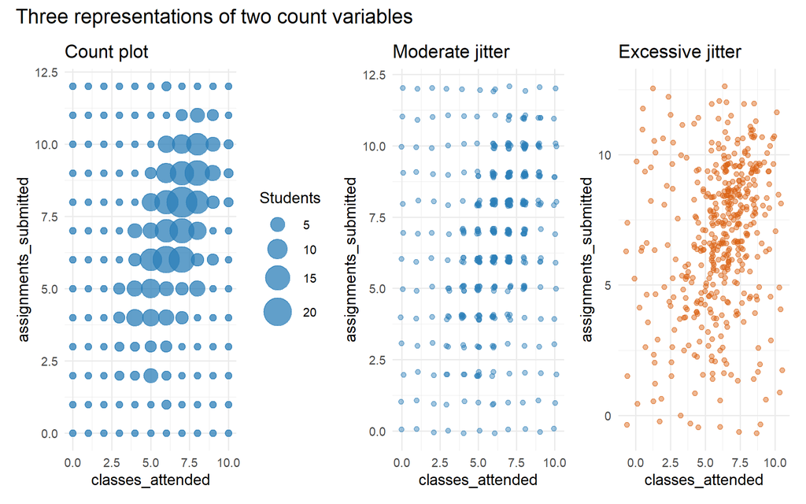

```r
library(patchwork)

p_count <- ggplot(
  students,
  aes(x = classes_attended, y = assignments_submitted)
) +
  geom_count(colour = "#2C7FB8", alpha = 0.75) +
  scale_size_area(max_size = 10) +
  labs(
    title = "Count plot",
    size = "Students"
  ) +
  theme_minimal()

set.seed(123)

p_small <- ggplot(
  students,
  aes(x = classes_attended, y = assignments_submitted)
) +
  geom_jitter(
    width = 0.10,
    height = 0.10,
    alpha = 0.45,
    colour = "#2C7FB8"
  ) +
  labs(title = "Moderate jitter") +
  theme_minimal()

set.seed(123)

p_large <- ggplot(
  students,
  aes(x = classes_attended, y = assignments_submitted)
) +
  geom_jitter(
    width = 0.70,
    height = 0.70,
    alpha = 0.45,
    colour = "#D95F0E"
  ) +
  labs(title = "Excessive jitter") +
  theme_minimal()

p_count + p_small + p_large +
  plot_annotation(
    title = "Three representations of two count variables"
  )
```

A useful question for the students is:

> At what point does jittering stop revealing overlap and start concealing the structure of the original data?

The key principle is that jitter should be small relative to the distance between possible values.

## Suggested classroom question

> Both variables are counts. Why does the ordinary scatter plot provide an incomplete representation of their relationship? Which graphical element should represent the number of observations sharing the same pair of values?

### Take-home message

> When two variables are discrete, observations often overlap. A count plot or joint-frequency heatmap displays both the relationship between the variables and the frequency of each observed combination.

> **Note on AI assistance**

> These teaching materials were prepared with assistance from ChatGPT (OpenAI) in drafting explanations, developing examples, and generating R code. The author retains responsibility for the final content.